# University of Kansas Machine Learning Challenge #3

Zach Meyen

## Introduction

This challenge differs from the last two as it is much more “exam-like”. It focuses on Apriori algorthims and exploratory data analysis. I have edited the final submission into an R Markdown document so the code used can be visible. I scored 2nd in this, with only 1 error. I took first overall.

## Problem Statement

Your problem for the last challenge in this competition will be to perform a market basket analysis on the 9,532 transactions provided in the Wheatfields.csv data set. Because there is no metric like an MSE for market basket analysis you will need to answer the following ten questions and will be graded on a score of 0-100 points. The questions and point break down are listed below. Also listed, is a description of the data provided as well as resources that will be a good starting point for your research into the apriori algorithm.

## Part 1: Visualizations

The first of these questions just ask to make visualizations to answer specific questions. I thought of it as as form of exploratory data analysis. First, I clean up the data for our visualizations.

```r
library(ggplot2)
library(dplyr)
library(plyr)
library(wesanderson)
data <- read.csv("Wheatfieldsr.csv")

print(levels(data$HOUR))
data$HOUR = factor(data$HOUR, levels =c("1 AM", "7 AM",
                                                    "8 AM", "9 AM",
                                                    "10 AM","11 AM",
                                                    "12 PM", "1 PM",
                                                    "2 PM", "3 PM",
                                                    "4 PM", "5 PM",
                                                    "6 PM", "7 PM",
                                                    "8 PM", "9 PM",
                                                    "10 PM","11 PM"))

data$DAY = factor(data$DAY, levels = c("Sunday", "Monday",
                                                               "Tuesday", "Wednesday",
                                                               "Thursday","Friday","Saturday"))
hrlist <- c("7 AM",
"8 AM", "9 AM",
"10 AM","11 AM",
"12 PM", "1 PM",
"2 PM", "3 PM",
"4 PM", "5 PM",
"6 PM", "7 PM")
```

Here I re-label the categories to make them more friendly to read. I make the variable ‘hrlist’ to limit the dataframe to contain data within business hours: 7 AM to 7 PM.

```r
dataq1 <- data[data$HOUR %in% hrlist,]
```

**1. What days of the week have the highest sales figures?**

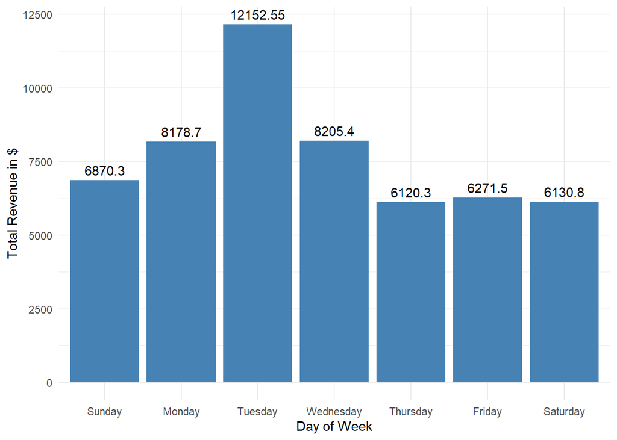

```r
dataq2 <- aggregate(data$REV, by =list(data$DAY), FUN=sum)

RevPerDay <- ggplot(dataq2, aes(x=Group.1,y=x)) +
  geom_bar(stat="identity", fill = "steelblue") +
  labs(x="Day of Week", y = "Total Revenue in $") +
  geom_text(aes(label=x),vjust = -.5) +
  theme_minimal()

RevPerDay
```

I used revenue rather than individual sales or quantity sold. Revenue is a more accurate measure since quantity can vary sale to sale

**2. What are our top 10 products in terms of highest sales?**

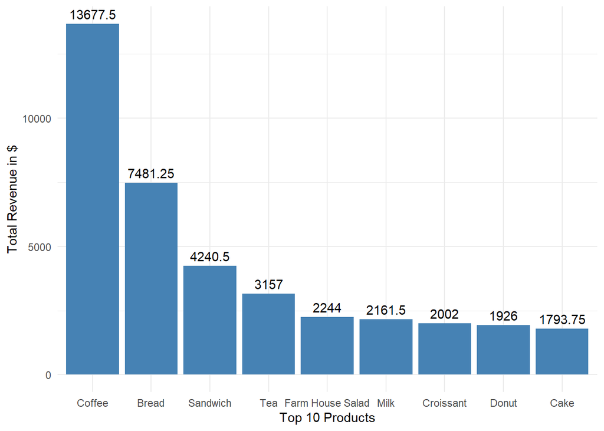

```r
selected <- c("Coffee", "Bread", "Sandwich", "Tea", "Farm House Salad", "Milk","Hot Chocolate", "Croissant", "Donut", "Cake")
data2<- data[data$PRODUCT %in% selected,]
dataq3 <- aggregate(data2$REV, by=list(data2$PRODUCT), FUN = sum)
RevPerProduct <- ggplot(dataq3, aes(x=reorder(Group.1, -x), y=x)) +
  geom_bar(stat="identity", fill = "steelblue") +
  labs(x="Top 10 Products", y = "Total Revenue in $") +
  geom_text(aes(label=x), vjust = -.5) +
  theme_minimal()
RevPerProduct
```

This is revenue rather than individual sales.

**3. During which hours of the day does WheatFields have the highest sales figures?**

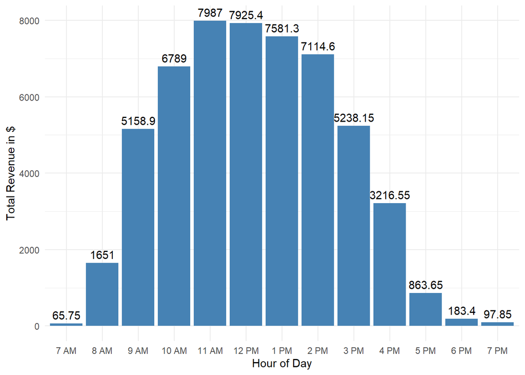

```r
dataq1 <- data[data$HOUR %in% hrlist,]
dataq1.1 <- aggregate(dataq1$REV, by=list(dataq1$HOUR), FUN = sum)

RevPerHour <- ggplot(dataq1.1, aes(x=Group.1, y=x)) +
  geom_bar(stat="identity", fill = "steelblue") +
  labs(x="Hour of Day", y= "Total Revenue in $") +
  geom_text(aes(label = x),vjust = -0.5) +
  theme_minimal()

RevPerHour
```

I removed columns representing 1AM, 8PM, 9PM, 10PM, and 11PM. These were very low sales and are either errors or employees ringing up items outside of store hours.

**4. WheatFields bakers’ bread fresh every morning. To help the bakers better understand how much bread they should make each morning, find the average quantity of bread sold for each day of the week.**

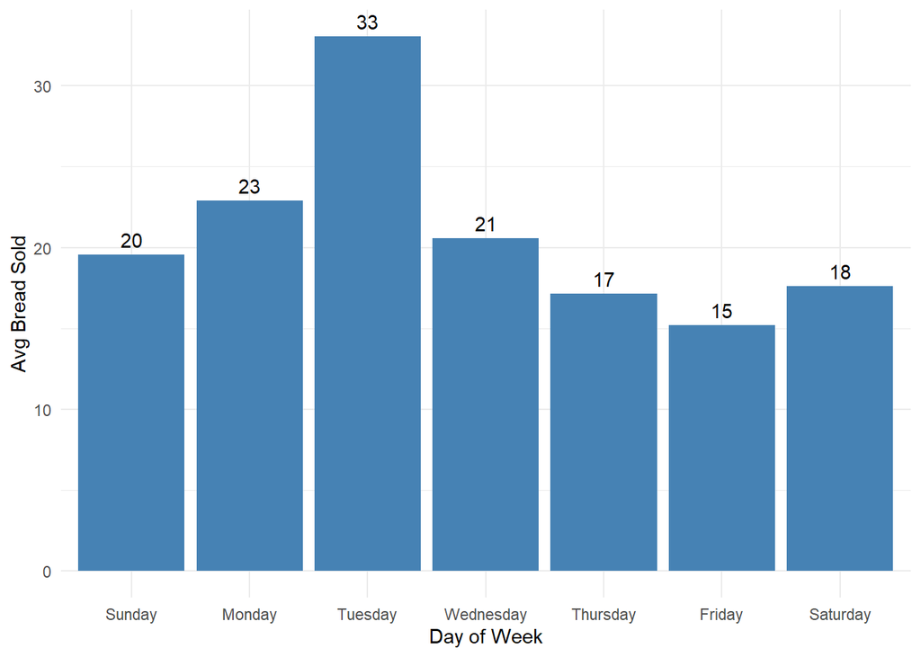

```r
datan <- subset(data, PRODUCT == "Bread", select = c(DATE,DAY, QUANTITY,PRODUCT))

days <- list("Sunday", "Monday",
          "Tuesday", "Wednesday",
          "Thursday","Friday","Saturday")

#bread sold per day
aggbread <- aggregate(datan$QUANTITY, by=list(datan$DATE, datan$DAY), FUN=sum)
aggbread2 <- aggregate(aggbread$x, by=list(aggbread$Group.2), FUN=mean)
dayc<- count(datan$DAY)

SalePerDay <- ggplot(aggbread2, aes(x=Group.1, y=x, label = Group.1)) +
  geom_bar(stat="identity", fill = "steelblue") +
  labs(x= "Day of Week", y="Avg Bread Sold") +
  geom_text(aes(label=round(x), vjust = -.5)) +
  theme_minimal()
SalePerDay
```

This chart shows the average units of bread sold each day.

**5. Help them, with a visualization, to find out which days of the week they have their top sales. What do you see with the graph?**

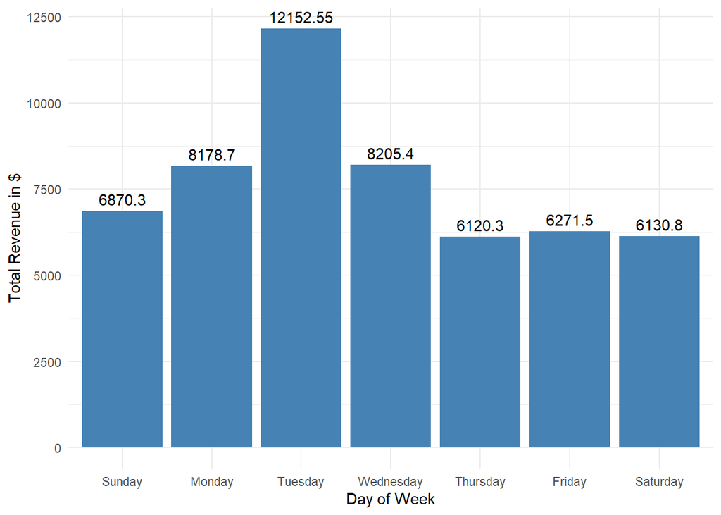

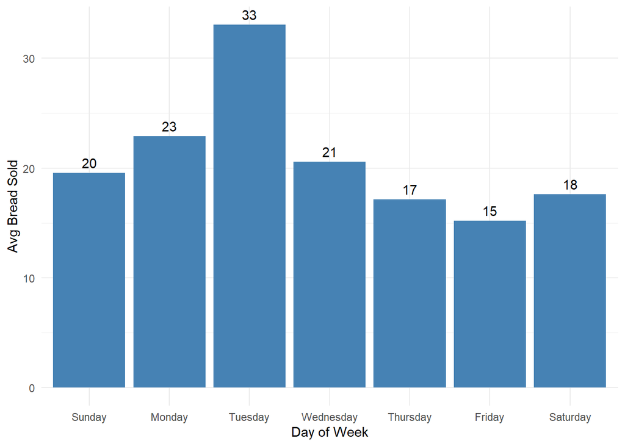

These are the same graphs used in question 1 and 4. Tuesday is the busiest day of the week for bread sales as well as total sales. It is safe to say there is a sale or special on Tuesdays that is not presented in the data.

## Part 2: Apriori Questions Regarding Products

Apriori algorithms find association within a dataset. In this case, we are using them to find assocaitions of products.

```r
library(arules)
```

```r
library(arulesViz)
data <- read.csv("Wheatfields.csv")

#create dataframe for transactions and product
trans <- read.transactions("Wheatfields.csv", format="single", cols=c(3,5), sep=",", rm.duplicates=TRUE)
#create dataframe for transactions and price
trans2 <- read.transactions("Wheatfields.csv ", format="single", cols=c(3,7), sep=",", rm.duplicates=TRUE)
```

**6. What are the five products that have the highest frequency?**

```r
ap <- apriori(trans,parameter = list(sup = 0.02, conf = 0.1,minlen=2))
summary(ap)
inspect(ap)
```

```r
frequentItems <- eclat(trans, parameter = list(supp = 0.07, maxlen = 15))
```

```
## Eclat
##
## parameter specification:
##  tidLists support minlen maxlen            target  ext
##     FALSE    0.07      1     15 frequent itemsets TRUE
##
## algorithmic control:
##  sparse sort verbose
##       7   -2    TRUE
##
## Absolute minimum support count: 667
##
## create itemset ...
## set transactions ...[95 item(s), 9532 transaction(s)] done [0.00s].
## sorting and recoding items ... [7 item(s)] done [0.00s].
## creating bit matrix ... [7 row(s), 9532 column(s)] done [0.00s].
## writing  ... [8 set(s)] done [0.00s].
## Creating S4 object  ... done [0.00s].
```

```r
inspect(frequentItems)
```

```
##     items          support    transIdenticalToItemsets count
## [1] {Bread,Coffee} 0.08938313  852                      852
## [2] {Coffee}       0.47503147 4528                     4528
## [3] {Bread}        0.32490558 3097                     3097
## [4] {Tea}          0.14162820 1350                     1350
## [5] {Cake}         0.10312631  983                      983
## [6] {Milk}         0.07899706  753                      753
## [7] {Donut}        0.08550147  815                      815
## [8] {Sandwich}     0.07133865  680                      680
```

The most frequent items are coffee, bread, tea, cake, and donuts.

**7. Assuming a minimum Support of .02, if a customer purchases a Donut what product do we have the highest confidence they will purchase next? What is the rule’s; Support, Confidence, and Lift?**

```r
donut <- apriori(trans, parameter = list (supp=0.02,conf = 0.15,minlen=2),
                 appearance = list(default="rhs",lhs="Donut"), control = list (verbose=F))

donut_conf <- sort (donut, by="confidence", decreasing=TRUE)
inspect(head(donut_conf))
```

```
##     lhs        rhs      support   confidence coverage   lift     count
## [1] {Donut} => {Coffee} 0.0472094 0.5521472  0.08550147 1.162338 450
## [2] {Donut} => {Bread}  0.0289551 0.3386503  0.08550147 1.042304 276
```

Coffee is the most likely product. Support: 0.0472094 Confidence: 0.5521472 Lift: 1.162338

**8. Using support and confidence parameters of .02 and .25 respectively, what rule has the highest lift? What is the rule’s; support, confidence and lift? 10 points**

```r
ap8 <- apriori(trans, parameter = list(supp=.02, conf=.25))
inspect(ap8)
```

```r
conf8 <- sort (ap8, by="lift", decreasing=TRUE)
inspect(head(conf8))
```

```
##     lhs            rhs      support    confidence coverage   lift     count
## [1] {Toast}     => {Coffee} 0.02349979 0.7044025  0.03336131 1.482854 224
## [2] {Croissant} => {Coffee} 0.03493496 0.5692308  0.06137222 1.198301 333
## [3] {Donut}     => {Coffee} 0.04720940 0.5521472  0.08550147 1.162338 450
## [4] {Juice}     => {Coffee} 0.02045741 0.5342466  0.03829207 1.124655 195
## [5] {Milk}      => {Coffee} 0.04206882 0.5325365  0.07899706 1.121055 401
## [6] {Sandwich}  => {Coffee} 0.03797734 0.5323529  0.07133865 1.120669 362
```

Toast => coffee is the highest rule

Support: 0.02349979 Confidence: 0.7044025 Lift:1.482854

**9. Using support and confidence parameters of .001 and .1 respectively, what are the 4 rules regarding a customer whose first purchase is Milk (lhs = {Milk}? What are the rules; support, confidence, and lift?**

```r
ap9 <- apriori(trans, parameter = list (supp=0.001,conf = 0.1),
                 appearance = list(default="rhs",lhs="Milk"), control = list (verbose=F))
inspect(ap9)
```

```
##     lhs       rhs        support     confidence coverage   lift      count
## [1] {}     => {Cake}     0.103126311 0.1031263  1.00000000 1.0000000  983
## [2] {}     => {Tea}      0.141628200 0.1416282  1.00000000 1.0000000 1350
## [3] {}     => {Bread}    0.324905581 0.3249056  1.00000000 1.0000000 3097
## [4] {}     => {Coffee}   0.475031473 0.4750315  1.00000000 1.0000000 4528
## [5] {Milk} => {Sandwich} 0.009127151 0.1155378  0.07899706 1.6195688   87
## [6] {Milk} => {Tea}      0.018254301 0.2310757  0.07899706 1.6315656  174
## [7] {Milk} => {Bread}    0.020562316 0.2602922  0.07899706 0.8011317  196
## [8] {Milk} => {Coffee}   0.042068821 0.5325365  0.07899706 1.1210552  401
```

[5] {Milk} => {Sandwich} 0.009127151 0.1155378 0.07899706 1.6195688 87

[6] {Milk} => {Tea} 0.018254301 0.2310757 0.07899706 1.6315656 174

[7] {Milk} => {Bread} 0.020562316 0.2602922 0.07899706 0.8011317 196

[8] {Milk} => {Coffee} 0.042068821 0.5325365 0.07899706 1.1210552 401

## Part 3: Apriori Questions Regarding Categories

**10. Assuming a minimum Support of .02, if a customer purchases an item from the Drink category, what Item category do we have the highest confidence they will purchase from next? What is the rule’s; support, confidence, and lift?**

```r
drink <- apriori(trans2, parameter = list (supp=0.02, conf=.08),
                 appearance = list(default="rhs",lhs="Drink"), control = list (verbose=F))

drink_conf <- sort (drink, by="confidence", decreasing=TRUE)
inspect(head(drink_conf))
```

```
##     lhs        rhs          support   confidence coverage  lift      count
## [1] {}      => {Side Order} 0.4211078 0.4211078  1.0000000 1.0000000 4014
## [2] {}      => {Pastry}     0.3422157 0.3422157  1.0000000 1.0000000 3262
## [3] {Drink} => {Pastry}     0.2181074 0.3399836  0.6415233 0.9934777 2079
## [4] {Drink} => {Side Order} 0.1945027 0.3031889  0.6415233 0.7199792 1854
## [5] {}      => {Food}       0.1766681 0.1766681  1.0000000 1.0000000 1684
## [6] {Drink} => {Food}       0.1115191 0.1738348  0.6415233 0.9839630 1063
```

```r
inspect(drink)
```

```
##     lhs        rhs          support    confidence coverage  lift      count
## [1] {}      => {Dessert}    0.11393202 0.1139320  1.0000000 1.0000000 1086
## [2] {}      => {Food}       0.17666807 0.1766681  1.0000000 1.0000000 1684
## [3] {}      => {Pastry}     0.34221569 0.3422157  1.0000000 1.0000000 3262
## [4] {}      => {Side Order} 0.42110785 0.4211078  1.0000000 1.0000000 4014
## [5] {Drink} => {Dessert}    0.08287872 0.1291905  0.6415233 1.1339263  790
## [6] {Drink} => {Food}       0.11151909 0.1738348  0.6415233 0.9839630 1063
## [7] {Drink} => {Pastry}     0.21810743 0.3399836  0.6415233 0.9934777 2079
## [8] {Drink} => {Side Order} 0.19450273 0.3031889  0.6415233 0.7199792 1854
```

{Drink} => {Pastry}  
Support: 0.21810743 Confidence: 0.3399836 Lift: 0.9934777

**11. If a customer purchases an item from the food category then an item from the side order category, what is our confidence that they will make a third purchase from the drink category {Food,Side Order} => {Drink}?**

```r
ap11 <- apriori(trans2, parameter = list (supp=0.001, conf=.01,minlen=3),
                 appearance = list(default="lhs", rhs="Drink"), control = list (verbose=F))
inspect(ap11)
```

```
##      lhs                                 rhs     support     confidence
## [1]  {Other,Side Order}               => {Drink} 0.001049098 0.5882353
## [2]  {Dessert,Snack}                  => {Drink} 0.004825850 0.7931034
## [3]  {Food,Snack}                     => {Drink} 0.007448594 0.7888889
## [4]  {Pastry,Snack}                   => {Drink} 0.012798993 0.6703297
## [5]  {Side Order,Snack}               => {Drink} 0.012274444 0.5969388
## [6]  {Dessert,Food}                   => {Drink} 0.011015527 0.7446809
## [7]  {Dessert,Pastry}                 => {Drink} 0.026647084 0.7236467
## [8]  {Dessert,Side Order}             => {Drink} 0.024863617 0.6950147
## [9]  {Food,Pastry}                    => {Drink} 0.027906001 0.7093333
## [10] {Food,Side Order}                => {Drink} 0.039865715 0.6643357
## [11] {Pastry,Side Order}              => {Drink} 0.065463701 0.5596413
## [12] {Dessert,Food,Snack}             => {Drink} 0.001258917 1.0000000
## [13] {Dessert,Pastry,Snack}           => {Drink} 0.001363827 0.6500000
## [14] {Dessert,Side Order,Snack}       => {Drink} 0.001993286 0.9047619
```

[output cut: 33 more lines]

{Food,Side Order} => {Drink} Support:0.039865715 Confidence: 0.6643357  
Lift: 1.0355597

## Evaluation

You will be evaluated on a 0 – 100 point scale, the breakdown of points is listed above with the questions.